# **Домашнее задание #3. Тренируем свой детектор**

На семинаре мы обсудили, разработали и попробовали `SSD`, в этом домашнем задании вам придется пойти дальше.

В домашнем задании вы:

- Создадите `Dataset` для задачи детектирования объектов.
- Разработаете `train, eval loop` для модели детектирования.
- Натренируете модель под целевую задачу.
- Оттестируете модель `SSD` на своих классах, реализуете расчет метрик для детектора
- Начнете разбираться в `open-source` коде
- (БОНУС) Реализуете возможность обработки видеопоследовательности.

**NB1. К программному коду должны прилагаться ваши осмысленные комментарии, пусть лишнего кода и текста не будет. Использовать могущество интернета можно, но указывайте ссылки откуда вы черпали помощь.**

**NB2. В этот раз будет много кода, все получится, надо только запланировать побольше времени.**

## **Часть 0. Вспоминаем код архитектуры и проверяем работоспособность детектора**

Программный код взят из семинара 7, где давались исчерпывающие комментарии. Если есть вопросы, то прежде всего пересмотрите семинар.

1. VGGBase - backbone модели детектирования (VGG16).
2. AuxiliaryConvolutions - вспомогательные свертки, для увеличения карт признаков (голов), где будет решаться задача классификации и локализации. Использование нескольких карт признаков позволяет детектировать объекты на разных масштабах (`conv4_3, conv7, conv8_2, conv9_2, conv10_2, conv11_2`)
3. PredictionConvolutions - предсказывающие свертки, дополнительные слои, где решается задача классификации и локализации.

```python
import os
import torch
import torchvision
import torch.nn.functional as F

from torch import nn
from math import sqrt
from torchvision import transforms as T
from PIL import Image, ImageDraw, ImageFont

import time
import torch.backends.cudnn as cudnn
import torch.optim
import torch.utils.data

device = torch.device("cuda" if torch.cuda.is_available() else "cpu")

import warnings
warnings.filterwarnings('ignore')


import matplotlib.pyplot as plt
from torch.utils.data import Dataset, DataLoader
from tqdm import tqdm
import numpy as np
from torch.optim.lr_scheduler import ReduceLROnPlateau
```

```python
torch.__version__
```

```
'1.12.1+cu113'
```

```python
## VGG Backbone
class VGGBase(nn.Module):
    def __init__(self):
        super(VGGBase, self).__init__()

        self.conv1_1 = nn.Conv2d(3, 64, kernel_size=3, padding=1)
        self.conv1_2 = nn.Conv2d(64, 64, kernel_size=3, padding=1)
        self.pool1 = nn.MaxPool2d(kernel_size=2, stride=2)

        self.conv2_1 = nn.Conv2d(64, 128, kernel_size=3, padding=1)
        self.conv2_2 = nn.Conv2d(128, 128, kernel_size=3, padding=1)
        self.pool2 = nn.MaxPool2d(kernel_size=2, stride=2)

        self.conv3_1 = nn.Conv2d(128, 256, kernel_size=3, padding=1)
        self.conv3_2 = nn.Conv2d(256, 256, kernel_size=3, padding=1)
        self.conv3_3 = nn.Conv2d(256, 256, kernel_size=3, padding=1)
        self.pool3 = nn.MaxPool2d(kernel_size=2, stride=2, ceil_mode=True)

        self.conv4_1 = nn.Conv2d(256, 512, kernel_size=3, padding=1)
        self.conv4_2 = nn.Conv2d(512, 512, kernel_size=3, padding=1)
        self.conv4_3 = nn.Conv2d(512, 512, kernel_size=3, padding=1)
        self.pool4 = nn.MaxPool2d(kernel_size=2, stride=2)

        self.conv5_1 = nn.Conv2d(512, 512, kernel_size=3, padding=1)
        self.conv5_2 = nn.Conv2d(512, 512, kernel_size=3, padding=1)
        self.conv5_3 = nn.Conv2d(512, 512, kernel_size=3, padding=1)
        self.pool5 = nn.MaxPool2d(kernel_size=3, stride=1, padding=1)

        self.conv6 = nn.Conv2d(512, 1024, kernel_size=3, padding=6, dilation=6)
        self.conv7 = nn.Conv2d(1024, 1024, kernel_size=1)

        self.load_pretrained_layers()

    def forward(self, image):
        out = F.relu(self.conv1_1(image))
        out = F.relu(self.conv1_2(out))
        out = self.pool1(out)

        out = F.relu(self.conv2_1(out))
        out = F.relu(self.conv2_2(out))
        out = self.pool2(out)

        out = F.relu(self.conv3_1(out))
        out = F.relu(self.conv3_2(out))
        out = F.relu(self.conv3_3(out))
        out = self.pool3(out)

        out = F.relu(self.conv4_1(out))
        out = F.relu(self.conv4_2(out))
        out = F.relu(self.conv4_3(out))
        conv4_3_feats = out

        out = self.pool4(out)
        out = F.relu(self.conv5_1(out))
        out = F.relu(self.conv5_2(out))
        out = F.relu(self.conv5_3(out))
        out = self.pool5(out)
        out = F.relu(self.conv6(out))
        conv7_feats = F.relu(self.conv7(out))

        return conv4_3_feats, conv7_feats

    def load_pretrained_layers(self):
        state_dict = self.state_dict()
        param_names = list(state_dict.keys())

        pretrained_state_dict = torchvision.models.vgg16(pretrained=True).state_dict()
        pretrained_param_names = list(pretrained_state_dict.keys())

        for i, param in enumerate(param_names[:-4]):
            state_dict[param] = pretrained_state_dict[pretrained_param_names[i]]

        conv_fc6_weight = pretrained_state_dict['classifier.0.weight'].view(4096, 512, 7, 7)
        conv_fc6_bias = pretrained_state_dict['classifier.0.bias']

        state_dict['conv6.weight'] = decimate(conv_fc6_weight, m=[4, None, 3, 3])
        state_dict['conv6.bias'] = decimate(conv_fc6_bias, m=[4])

        conv_fc7_weight = pretrained_state_dict['classifier.3.weight'].view(4096, 4096, 1, 1)
        conv_fc7_bias = pretrained_state_dict['classifier.3.bias']

        state_dict['conv7.weight'] = decimate(conv_fc7_weight, m=[4, 4, None, None])
        state_dict['conv7.bias'] = decimate(conv_fc7_bias, m=[4])

        self.load_state_dict(state_dict)

        print("\n Loaded backbone.\n")

def decimate(tensor, m):
    assert tensor.dim() == len(m)
    for d in range(tensor.dim()):
        if m[d] is not None:
            tensor = tensor.index_select(dim=d, index=torch.arange(start=0, end=tensor.size(d), step=m[d]).long())
    return tensor
```

```python
class AuxiliaryConvolutions(nn.Module):
    def __init__(self):
        super(AuxiliaryConvolutions, self).__init__()
        self.conv8_1 = nn.Conv2d(1024, 256, kernel_size=1, padding=0)
        self.conv8_2 = nn.Conv2d(256, 512, kernel_size=3, stride=2, padding=1)

        self.conv9_1 = nn.Conv2d(512, 128, kernel_size=1, padding=0)
        self.conv9_2 = nn.Conv2d(128, 256, kernel_size=3, stride=2, padding=1)

        self.conv10_1 = nn.Conv2d(256, 128, kernel_size=1, padding=0)
        self.conv10_2 = nn.Conv2d(128, 256, kernel_size=3, padding=0)

        self.conv11_1 = nn.Conv2d(256, 128, kernel_size=1, padding=0)
        self.conv11_2 = nn.Conv2d(128, 256, kernel_size=3, padding=0)

    def forward(self, conv7_feats):
        out = F.relu(self.conv8_1(conv7_feats))
        out = F.relu(self.conv8_2(out))
        conv8_2_feats = out

        out = F.relu(self.conv9_1(out))
        out = F.relu(self.conv9_2(out))
        conv9_2_feats = out

        out = F.relu(self.conv10_1(out))
        out = F.relu(self.conv10_2(out))
        conv10_2_feats = out

        out = F.relu(self.conv11_1(out))
        out = F.relu(self.conv11_2(out))
        conv11_2_feats = out

        return conv8_2_feats, conv9_2_feats, conv10_2_feats, conv11_2_feats


class PredictionConvolutions(nn.Module):
    def __init__(self, n_classes):
        super(PredictionConvolutions, self).__init__()
        self.n_classes = n_classes

        n_boxes = {'conv4_3': 4, 'conv7': 6, 'conv8_2': 6,
                   'conv9_2': 6, 'conv10_2': 4, 'conv11_2': 4}

        self.loc_conv4_3 = nn.Conv2d(512, n_boxes['conv4_3'] * 4, kernel_size=3, padding=1)
        self.loc_conv7 = nn.Conv2d(1024, n_boxes['conv7'] * 4, kernel_size=3, padding=1)
        self.loc_conv8_2 = nn.Conv2d(512, n_boxes['conv8_2'] * 4, kernel_size=3, padding=1)
        self.loc_conv9_2 = nn.Conv2d(256, n_boxes['conv9_2'] * 4, kernel_size=3, padding=1)
        self.loc_conv10_2 = nn.Conv2d(256, n_boxes['conv10_2'] * 4, kernel_size=3, padding=1)
        self.loc_conv11_2 = nn.Conv2d(256, n_boxes['conv11_2'] * 4, kernel_size=3, padding=1)

        self.cl_conv4_3 = nn.Conv2d(512, n_boxes['conv4_3'] * n_classes, kernel_size=3, padding=1)
        self.cl_conv7 = nn.Conv2d(1024, n_boxes['conv7'] * n_classes, kernel_size=3, padding=1)
        self.cl_conv8_2 = nn.Conv2d(512, n_boxes['conv8_2'] * n_classes, kernel_size=3, padding=1)
        self.cl_conv9_2 = nn.Conv2d(256, n_boxes['conv9_2'] * n_classes, kernel_size=3, padding=1)
        self.cl_conv10_2 = nn.Conv2d(256, n_boxes['conv10_2'] * n_classes, kernel_size=3, padding=1)
        self.cl_conv11_2 = nn.Conv2d(256, n_boxes['conv11_2'] * n_classes, kernel_size=3, padding=1)

    def forward(self, conv4_3_feats, conv7_feats, conv8_2_feats, conv9_2_feats, conv10_2_feats, conv11_2_feats):
        batch_size = conv4_3_feats.size(0)

        l_conv4_3 = self.loc_conv4_3(conv4_3_feats)
        l_conv4_3 = l_conv4_3.permute(0, 2, 3, 1).contiguous()
        l_conv4_3 = l_conv4_3.view(batch_size, -1, 4)

        l_conv7 = self.loc_conv7(conv7_feats)
        l_conv7 = l_conv7.permute(0, 2, 3, 1).contiguous()
        l_conv7 = l_conv7.view(batch_size, -1, 4)

        l_conv8_2 = self.loc_conv8_2(conv8_2_feats)
        l_conv8_2 = l_conv8_2.permute(0, 2, 3, 1).contiguous()
        l_conv8_2 = l_conv8_2.view(batch_size, -1, 4)

        l_conv9_2 = self.loc_conv9_2(conv9_2_feats)
        l_conv9_2 = l_conv9_2.permute(0, 2, 3, 1).contiguous()
        l_conv9_2 = l_conv9_2.view(batch_size, -1, 4)

        l_conv10_2 = self.loc_conv10_2(conv10_2_feats)
        l_conv10_2 = l_conv10_2.permute(0, 2, 3, 1).contiguous()
        l_conv10_2 = l_conv10_2.view(batch_size, -1, 4)

        l_conv11_2 = self.loc_conv11_2(conv11_2_feats)
        l_conv11_2 = l_conv11_2.permute(0, 2, 3, 1).contiguous()
        l_conv11_2 = l_conv11_2.view(batch_size, -1, 4)

        c_conv4_3 = self.cl_conv4_3(conv4_3_feats)
        c_conv4_3 = c_conv4_3.permute(0, 2, 3, 1).contiguous()
        c_conv4_3 = c_conv4_3.view(batch_size, -1, self.n_classes)

        c_conv7 = self.cl_conv7(conv7_feats)
        c_conv7 = c_conv7.permute(0, 2, 3, 1).contiguous()
        c_conv7 = c_conv7.view(batch_size, -1,self.n_classes)

        c_conv8_2 = self.cl_conv8_2(conv8_2_feats)
        c_conv8_2 = c_conv8_2.permute(0, 2, 3, 1).contiguous()
        c_conv8_2 = c_conv8_2.view(batch_size, -1, self.n_classes)

        c_conv9_2 = self.cl_conv9_2(conv9_2_feats)
        c_conv9_2 = c_conv9_2.permute(0, 2, 3, 1).contiguous()
        c_conv9_2 = c_conv9_2.view(batch_size, -1, self.n_classes)

        c_conv10_2 = self.cl_conv10_2(conv10_2_feats)
        c_conv10_2 = c_conv10_2.permute(0, 2, 3, 1).contiguous()
        c_conv10_2 = c_conv10_2.view(batch_size, -1, self.n_classes)

        c_conv11_2 = self.cl_conv11_2(conv11_2_feats)
        c_conv11_2 = c_conv11_2.permute(0, 2, 3, 1).contiguous()
        c_conv11_2 = c_conv11_2.view(batch_size, -1, self.n_classes)

        locs = torch.cat([l_conv4_3, l_conv7, l_conv8_2, l_conv9_2, l_conv10_2, l_conv11_2], dim=1)
        classes_scores = torch.cat([c_conv4_3, c_conv7, c_conv8_2, c_conv9_2, c_conv10_2, c_conv11_2], dim=1)

        return locs, classes_scores
```

```python
class SSD300_(nn.Module):
    def __init__(self, n_classes):
        super(SSD300_, self).__init__()
        self.n_classes = n_classes

        self.base = VGGBase()
        self.aux_convs = AuxiliaryConvolutions()
        self.pred_convs = PredictionConvolutions(n_classes)

        self.priors_cxcy = self.create_prior_boxes()
        self.rescale_factors = nn.Parameter(torch.FloatTensor(1, 512, 1, 1))
        nn.init.constant_(self.rescale_factors, 20)

    def create_prior_boxes(self):
        fmap_dims = {'conv4_3': 38, 'conv7': 19, 'conv8_2': 10,
                     'conv9_2': 5, 'conv10_2': 3, 'conv11_2': 1}

        obj_scales = {'conv4_3': 0.1, 'conv7': 0.2, 'conv8_2': 0.375,
                      'conv9_2': 0.55, 'conv10_2': 0.725, 'conv11_2': 0.9}

        aspect_ratios = {'conv4_3': [1., 2., 0.5], 'conv7': [1., 2., 3., 0.5, 0.333],
                         'conv8_2': [1., 2., 3., 0.5, 0.333], 'conv9_2': [1., 2., 3., 0.5, 0.333],
                         'conv10_2': [1., 2., 0.5], 'conv11_2': [1., 2., 0.5]}

        prior_boxes = []
        fmaps = list(fmap_dims.keys())

        for k, fmap in enumerate(fmaps):
            for i in range(fmap_dims[fmap]):
                for j in range(fmap_dims[fmap]):
                    cx = (j + 0.5) / fmap_dims[fmap]
                    cy = (i + 0.5) / fmap_dims[fmap]

                    for ratio in aspect_ratios[fmap]:
                        prior_boxes.append([cx, cy, obj_scales[fmap] * sqrt(ratio), obj_scales[fmap] / sqrt(ratio)])

                        if ratio == 1.:
                            try:
                                additional_scale = sqrt(obj_scales[fmap] * obj_scales[fmaps[k + 1]])

                            except IndexError:
                                additional_scale = 1.
                            prior_boxes.append([cx, cy, additional_scale, additional_scale])

        prior_boxes = torch.FloatTensor(prior_boxes).to(device)
        prior_boxes.clamp_(0, 1)
        return prior_boxes

    def forward(self, image):
        conv4_3_feats, conv7_feats = self.base(image)

        norm = conv4_3_feats.pow(2).sum(dim=1, keepdim=True).sqrt()
        conv4_3_feats = conv4_3_feats / norm
        conv4_3_feats = conv4_3_feats * self.rescale_factors

        conv8_2_feats, conv9_2_feats, conv10_2_feats, conv11_2_feats = self.aux_convs(conv7_feats)

        locs, classes_scores = self.pred_convs(conv4_3_feats, conv7_feats, conv8_2_feats, conv9_2_feats,
                                              conv10_2_feats, conv11_2_feats)

        return locs, classes_scores
```

`g_c_x, g_c_y, g_w, g_h` - это четыре поправки, которые предсказывает результирующая модель.

Далее даны вспомогательные функции, которыми необходимо воспользоваться.

```python
#Вспомогательные функции
#(x_min, y_min, x_max, y_max) -> (c_x, c_y, w, h)
def xy_to_cxcy(xy):
    return torch.cat([(xy[:, 2:] + xy[:, :2]) / 2,  # c_x, c_y
                      xy[:, 2:] - xy[:, :2]], 1)  # w, h

#(c_x, c_y, w, h) -> (x_min, y_min, x_max, y_max)
def cxcy_to_xy(cxcy):
    return torch.cat([cxcy[:, :2] - (cxcy[:, 2:] / 2),  # x_min, y_min
                      cxcy[:, :2] + (cxcy[:, 2:] / 2)], 1)  # x_max, y_max

#(c_x, c_y, w, h) -> (g_c_x, g_c_y,  g_w, g_h)
def cxcy_to_gcxgcy(cxcy, priors_cxcy):
    return torch.cat([(cxcy[:, :2] - priors_cxcy[:, :2]) / (priors_cxcy[:, 2:] / 10),
                      torch.log(cxcy[:, 2:] / priors_cxcy[:, 2:]) * 5], 1)

#(g_c_x, g_c_y,  g_w, g_h) -> (c_x, c_y, w, h)
def gcxgcy_to_cxcy(gcxgcy, priors_cxcy):
    return torch.cat([gcxgcy[:, :2] * priors_cxcy[:, 2:] / 10 + priors_cxcy[:, :2],
                      torch.exp(gcxgcy[:, 2:] / 5) * priors_cxcy[:, 2:]], 1)


def find_intersection(set_1, set_2):
    lower_bounds = torch.max(set_1[:, :2].unsqueeze(1), set_2[:, :2].unsqueeze(0))
    upper_bounds = torch.min(set_1[:, 2:].unsqueeze(1), set_2[:, 2:].unsqueeze(0))
    intersection_dims = torch.clamp(upper_bounds - lower_bounds, min=0)
    return intersection_dims[:, :, 0] * intersection_dims[:, :, 1]


def find_jaccard_overlap(set_1, set_2):
    intersection = find_intersection(set_1, set_2)
    areas_set_1 = (set_1[:, 2] - set_1[:, 0]) * (set_1[:, 3] - set_1[:, 1])
    areas_set_2 = (set_2[:, 2] - set_2[:, 0]) * (set_2[:, 3] - set_2[:, 1])

    union = areas_set_1.unsqueeze(1) + areas_set_2.unsqueeze(0) - intersection
    return intersection / union
```

```python
class SSD300(SSD300_):
    def detect_objects(self, predicted_locs, predicted_scores, min_score, max_overlap, top_k):
        batch_size = predicted_locs.size(0)
        n_priors = self.priors_cxcy.size(0)

        predicted_scores = F.softmax(predicted_scores, dim=2)

        all_images_boxes = list()
        all_images_labels = list()
        all_images_scores = list()

        assert n_priors == predicted_locs.size(1) == predicted_scores.size(1)

        for i in range(batch_size):
            decoded_locs = cxcy_to_xy(gcxgcy_to_cxcy(predicted_locs[i], self.priors_cxcy))

            image_boxes = list()
            image_labels = list()
            image_scores = list()

            max_scores, best_label = predicted_scores[i].max(dim=1)

            for c in range(1, self.n_classes):
                class_scores = predicted_scores[i][:, c]
                score_above_min_score = class_scores > min_score
                n_above_min_score = score_above_min_score.sum().item()
                if n_above_min_score == 0:
                    continue

                class_scores = class_scores[score_above_min_score]
                class_decoded_locs = decoded_locs[score_above_min_score]

                class_scores, sort_ind = class_scores.sort(dim=0, descending=True)
                class_decoded_locs = class_decoded_locs[sort_ind]

                overlap = find_jaccard_overlap(class_decoded_locs, class_decoded_locs)

                # Non-Maximum Suppression (NMS)
                suppress = torch.zeros((n_above_min_score), dtype=torch.uint8).to(device)

                for box in range(class_decoded_locs.size(0)):
                    if suppress[box] == 1:
                        continue

                    suppress = suppress | (overlap[box] > max_overlap)
                    suppress[box] = 0

                image_boxes.append(class_decoded_locs[1 - suppress])
                image_labels.append(torch.LongTensor((1 - suppress).sum().item() * [c]).to(device))
                image_scores.append(class_scores[1 - suppress])

            if len(image_boxes) == 0:
                image_boxes.append(torch.FloatTensor([[0., 0., 1., 1.]]).to(device))
                image_labels.append(torch.LongTensor([0]).to(device))
                image_scores.append(torch.FloatTensor([0.]).to(device))

            image_boxes = torch.cat(image_boxes, dim=0)
            image_labels = torch.cat(image_labels, dim=0)
            image_scores = torch.cat(image_scores, dim=0)
            n_objects = image_scores.size(0)

            if n_objects > top_k:
                image_scores, sort_ind = image_scores.sort(dim=0, descending=True)
                image_scores = image_scores[:top_k]
                image_boxes = image_boxes[sort_ind][:top_k]
                image_labels = image_labels[sort_ind][:top_k]

            all_images_boxes.append(image_boxes)
            all_images_labels.append(image_labels)
            all_images_scores.append(image_scores)

        return all_images_boxes, all_images_labels, all_images_scores
```

```python
class MultiBoxLoss(nn.Module):
    def __init__(self, priors_cxcy, threshold=0.5, neg_pos_ratio=3, alpha=1.):
        super(MultiBoxLoss, self).__init__()

        self.priors_cxcy = priors_cxcy
        self.priors_xy = cxcy_to_xy(priors_cxcy)
        self.threshold = threshold
        self.neg_pos_ratio = neg_pos_ratio
        self.alpha = alpha

        self.smooth_l1 = nn.L1Loss()
        self.cross_entropy = nn.CrossEntropyLoss(reduce=False)

    def forward(self, predicted_locs, predicted_scores, boxes, labels):
        batch_size = predicted_locs.size(0)
        n_priors = self.priors_cxcy.size(0)
        n_classes = predicted_scores.size(2)

        assert n_priors == predicted_locs.size(1) == predicted_scores.size(1)

        true_locs = torch.zeros((batch_size, n_priors, 4), dtype=torch.float).to(device)
        true_classes = torch.zeros((batch_size, n_priors), dtype=torch.long).to(device)

        #каждую картинку отдельно обрабатываем
        for i in range(batch_size):
            n_objects = boxes[i].size(0)
            overlap = find_jaccard_overlap(boxes[i], self.priors_xy)
            overlap_for_each_prior, object_for_each_prior = overlap.max(dim=0)
            _, prior_for_each_object = overlap.max(dim=1)
            object_for_each_prior[prior_for_each_object] = torch.LongTensor(range(n_objects)).to(device)
            overlap_for_each_prior[prior_for_each_object] = 1.
            label_for_each_prior = labels[i][object_for_each_prior]
            label_for_each_prior[overlap_for_each_prior < self.threshold] = 0
            true_classes[i] = label_for_each_prior
            true_locs[i] = cxcy_to_gcxgcy(xy_to_cxcy(boxes[i][object_for_each_prior]), self.priors_cxcy)  # (8732, 4)

        positive_priors = true_classes != 0

        # LOCALIZATION LOSS
        loc_loss = self.smooth_l1(predicted_locs[positive_priors], true_locs[positive_priors])  #scalar

        # CONFIDENCE LOSS
        n_positives = positive_priors.sum(dim=1)
        n_hard_negatives = self.neg_pos_ratio * n_positives

        conf_loss_all = self.cross_entropy(predicted_scores.view(-1, n_classes), true_classes.view(-1))
        conf_loss_all = conf_loss_all.view(batch_size, n_priors)
        conf_loss_pos = conf_loss_all[positive_priors]
        conf_loss_neg = conf_loss_all.clone()
        conf_loss_neg[positive_priors] = 0.
        conf_loss_neg, _ = conf_loss_neg.sort(dim=1, descending=True)

        hardness_ranks = torch.LongTensor(range(n_priors)).unsqueeze(0).expand_as(conf_loss_neg).to(device)
        hard_negatives = hardness_ranks < n_hard_negatives.unsqueeze(1)
        conf_loss_hard_neg = conf_loss_neg[hard_negatives]

        conf_loss = (conf_loss_hard_neg.sum() + conf_loss_pos.sum()) / n_positives.sum().float()

        return conf_loss + self.alpha * loc_loss
```

```python
#будем использовать модель предобученную на Pascal VOC, вот его классы
voc_labels = ('background', 'aeroplane', 'bicycle', 'bird', 'boat', 'bottle', 'bus', 'car', 'cat', 'chair', 'cow', 'diningtable',
              'dog', 'horse', 'motorbike', 'person', 'pottedplant', 'sheep', 'sofa', 'train', 'tvmonitor')

label_map = {k: v for v, k in enumerate(voc_labels)}
rev_label_map = {v: k for k, v in label_map.items()}

# Color map for bounding boxes of detected objects from https://sashat.me/2017/01/11/list-of-20-simple-distinct-colors/
distinct_colors = ['#e6194b', '#3cb44b', '#ffe119', '#0082c8', '#f58231', '#911eb4', '#46f0f0', '#f032e6',
                   '#d2f53c', '#fabebe', '#008080', '#000080', '#aa6e28', '#fffac8', '#800000', '#aaffc3', '#808000',
                   '#ffd8b1', '#e6beff', '#808080', '#FFFFFF']
label_color_map = {k: distinct_colors[i] for i, k in enumerate(label_map.keys())}
```

### **Задание 0** (1 балл)

[Скачайте](https://drive.google.com/file/d/1ySBa0zbcd-59zan-8c0gwbmywd8dEq5h/view?usp=sharing) обученные на `Pascal VOC` веса для этой модели. Положите их себе на Google Drive. Если вы пользуетесь платформой Kaggle для выполнения домашнего задания, прочитайте https://datascience.stackexchange.com/questions/53023/import-data-from-google-drive-to-kaggle-kernel

Подгрузите веса и проверьте работоспособность модели на одном из изображений

```python
ssd = SSD300(n_classes = len(voc_labels))
```

```
 Loaded backbone.
```

```python
ssd = ssd.to(device)
```

```python
#напоминаю как присоединить драйв
from google.colab import drive
drive.mount("/content/gdrive", force_remount=True)
```

```python
#указываем путь к данным
data_path = '/content/gdrive/MyDrive/AI Masters'
checkpoint = torch.load(data_path + '/checkpoint_ssd300_pascal_voc.pth', map_location=device)
```

```python
#загружаем веса
ssd.load_state_dict(checkpoint['state_dict'])
```

```
<All keys matched successfully>
```

```python
#вот из таких частей должен будет состоять будущий трансформ
resize = T.Resize((300, 300))
to_tensor = T.ToTensor()
normalize = T.Normalize(mean=[0.485, 0.456, 0.406],
                                 std=[0.229, 0.224, 0.225])

transform = T.Compose([resize, to_tensor, normalize])
```

```python
#тут считайте картинку с помощью PIL и подготовьте к подаче в детектор
original_image = Image.open('/content/gdrive/MyDrive/AI Masters/g0Ayf1hBiqc.jpg')

image = transform(original_image)
image = image.reshape(-1, 3, 300, 300)
image = image.to(device)
```

```python
#получите предсказания детектора и используйте ssd.detect_objects() чтобы получить финальные боксы,
#для ssd порог на скор приемлемо брать в диапазоне 0.5-0.7, порог для nms в диапазоне 0.3-0.5
locs, scores = ssd(image)
det_boxes, det_labels, det_scores = ssd.detect_objects(locs.detach(), scores.detach(), min_score=0.5, max_overlap=0.5, top_k=1)
```

```python
#нам надо полученные относительные боксы накинуть на первоначальный размер изображения
original_dims = torch.FloatTensor([original_image.width, original_image.height, original_image.width, original_image.height]).unsqueeze(0)
det_boxes = det_boxes[0].to('cpu') * original_dims
det_labels = [rev_label_map[l] for l in det_labels[0].to('cpu').tolist()]
```

```python
#функция для рисования
def draw_boxes(original_image, det_boxes, det_labels):
  annotated_image = original_image.copy()
  draw = ImageDraw.Draw(annotated_image)
  font = ImageFont.load_default()

  for i in range(det_boxes.size(0)):
    # Boxes
    box_location = det_boxes[i].tolist()
    draw.rectangle(xy=box_location, outline=label_color_map[det_labels[i]])
    draw.rectangle(xy=[l + 1. for l in box_location], outline=label_color_map[det_labels[i]])

    # Text
    text_size = font.getsize(det_labels[i].upper())
    text_location = [box_location[0] + 2., box_location[1] - text_size[1]]
    textbox_location = [box_location[0], box_location[1] - text_size[1], box_location[0] + text_size[0] + 4., box_location[1]]
    draw.rectangle(xy=textbox_location, fill=label_color_map[det_labels[i]])
    draw.text(xy=text_location, text=det_labels[i].upper(), fill='white',font=font)

  return annotated_image
```

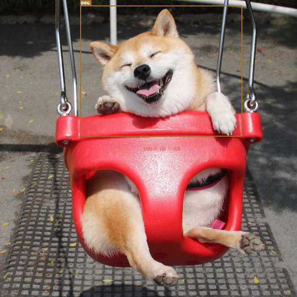

```python
draw_boxes(original_image, det_boxes, det_labels)
```

Попробуйте поиграться с гиперпараметрами чтобы получилось лучшее качество на этом изображении.

В целом результат посредственый -- обучен детектор на небольшой базе `Pascal VOC`, мы используем не самую сильную его версию - `ssd300`, но даже с такими вводными у нас получится сделать интересное, let's get it started.

## **Часть 1. Разбираемся с данными**

На этот раз у нас будет небольшой набор данных из пешеходов. Данные можно скачать [здесь](https://drive.google.com/file/d/1_8mnenRzV6ylr7L29LuhQHKd82GNzU9y/view?usp=sharing).

Для того, чтобы учить сеть, нужен будет `Dataloader`, а значит и собственный `Dataset`. Чтобы собрать `Dataset`, надо понять как выглядят данные и аннотация, а также какие данные понадобятся вашей сетке для обучения. Данные будут не совсем типичные для задачи - у вас будут изображения и маски объектов, из масок вам придется сделать боксы, которые требуются для `MultiBoxLoss`.

Набор данных разделен на тренировочну и тестовые выборки, `train` и `test`.

**Нужно, чтобы данные лежали у вас архивом на ГуглДиске, тогда, поменяв директорию, я смогу воспроизвести и оценить ваши результаты.**

### **Задание 1** (1 балл)

Разархивируйте данные, загрузите и посмотрите на изображение и соответствующие маски (соответствие происходит явно по имени), напишите функцию, которая по маске рассчитывают бокс, отрисуйте 4-5 фото с полученными боксами. Эту функцию будем использовать в `Dataset`.

```python
import zipfile
with zipfile.ZipFile('/content/gdrive/MyDrive/AI Masters/PennFudanPed.zip', 'r') as zip_ref:
    zip_ref.extractall('/content/gdrive/MyDrive/AI Masters/')
```

```python
from torchvision.utils import draw_bounding_boxes
from torchvision.ops import masks_to_boxes
```

Функция для рисования картинок

```python
# https://pytorch.org/vision/main/auto_examples/plot_repurposing_annotations.html

def show(imgs):
    figure = plt.figure(figsize=(12, 12))
    if not isinstance(imgs, list):
        imgs = [imgs]
    fix, axs = plt.subplots(ncols=len(imgs), squeeze=False)
    for i, img in enumerate(imgs):
        img = img.detach()
        img = T.functional.to_pil_image(img)
        axs[0, i].imshow(img)
        axs[0, i].set(xticklabels=[], yticklabels=[], xticks=[], yticks=[])
```

Изначально маска - вещественная матрица, в которой ненулевые значения отражают детектированные объекты. Построим набор булевых масок, количество которых совпадает с количеством объектов, каждая из которых отражает отражает расположение конкретного объекта на картинке. А затем по построенным маскам найдём якоря(то есть вершины прямоугольников, в которых располагаются объекты в формате (xmin, ymin, xmax, ymax)). Обернём это в функцию

```python
# https://pytorch.org/vision/main/auto_examples/plot_repurposing_annotations.html

def mask_to_boxes(mask):

    obj_ids = torch.unique(mask)

    obj_ids = obj_ids[1:]

    masks = mask == obj_ids[:, None, None]

    boxes = masks_to_boxes(masks)

    return boxes
```

```python
to_tensor = T.ToTensor()
t = T.Compose([to_tensor])
```

```python
resize = T.Resize((300, 300))
r = T.Compose([resize])
```

Наисуем найденные прямоугольники на картинке

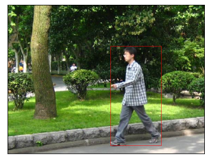

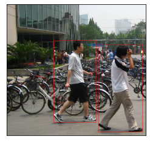

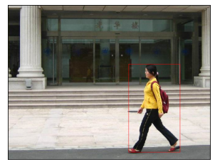

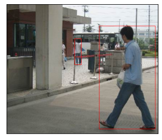

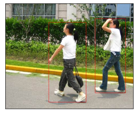

```python
for i in range(5):
    sample_idx = torch.randint(1, 50, size=(1,)).item()
    if sample_idx < 10:
        im = Image.open('/content/gdrive/MyDrive/AI Masters/PennFudanPed/Images/train/FudanPed0000'+str(sample_idx)+'.png')
        m = Image.open('/content/gdrive/MyDrive/AI Masters/PennFudanPed/Masks/train/FudanPed0000'+str(sample_idx)+'_mask.png')
    else:
        im = Image.open('/content/gdrive/MyDrive/AI Masters/PennFudanPed/Images/train/FudanPed000'+str(sample_idx)+'.png')
        m = Image.open('/content/gdrive/MyDrive/AI Masters/PennFudanPed/Masks/train/FudanPed000'+str(sample_idx)+'_mask.png')
    img = (t(im) * 255).type(torch.uint8)
    mask = t(m)
    boxes = mask_to_boxes(mask)
    drawn_boxes = draw_bounding_boxes(img, boxes, colors="red")
    show(drawn_boxes)
```

### **Задание 2** (2 балла)

Посмотрите, в каком виде данные нужны будут детектору и функции потерь для работы. Напишите `Dataset`, заведите для него загрузчики данных `DataLoader` для `train` и `test`, проверьте что всё работает.

```python
#http://senkler.blogspot.com/2011/04/python.html

class PedestrianSet(object):
    def __init__(self, root, train, transforms):
        self.root = root
        self.transforms = transforms
        if train:
            images_path = self.root + '/Images/train/'
            masks_path = self.root + '/Masks/train/'
            # получим имена всех файлов в каталоге
            imgs = sorted(os.listdir(images_path))
            masks = sorted(os.listdir(masks_path))
            # сохраним полные пути к файлам
            imgs = list(map(lambda name: os.path.join(images_path, name), imgs))
            masks = list(map(lambda name: os.path.join(masks_path, name), masks))
            # оставим только файлы определённого типа
            self.imgs = list(filter(lambda x: x.endswith('.png'), imgs))
            self.masks = list(filter(lambda x: x.endswith('.png'), masks))
        else:
            images_path = self.root + '/Images/test/'
            masks_path = self.root + '/Masks/test/'
            # получим имена всех файлов в каталоге
            imgs = sorted(os.listdir(images_path))
            masks = sorted(os.listdir(masks_path))
            # сохраним полные пути к файлам
            imgs = list(map(lambda name: os.path.join(images_path, name), imgs))
            masks = list(map(lambda name: os.path.join(masks_path, name), masks))
            # оставим только файлы определённого типа
            self.imgs = list(filter(lambda x: x.endswith('.png'), imgs))
            self.masks = list(filter(lambda x: x.endswith('.png'), masks))


    def __getitem__(self, idx):

        # считываем картинку и маску с помощью PIL
        img = Image.open(self.imgs[idx])
        # маску сразу преобразуем в тензор
        mask = t(Image.open(self.masks[idx]))

        boxes = mask_to_boxes(mask)

        #хоть класс в данных всего один, надо верно выставить label на основании pascal voc
        labels = torch.tensor([15 for i in range(len(boxes))])

        if self.transforms is not None:
            img = self.transforms(img)
            #img = img.reshape(-1, 3, 300, 300)

        return img, boxes, labels

    def __len__(self):
        return len(self.imgs)

    def collate_fn(batch):
        images_batch = torch.zeros(len(batch), 3, 300, 300)
        boxes_batch = []
        labels_batch = []
        for i, item in enumerate(batch):
            images_batch[i] = item[0]
            boxes_batch.append(item[1])
            labels_batch.append(item[2])
        return images_batch, boxes_batch, labels_batch
```

```python
path = '/content/gdrive/MyDrive/AI Masters/PennFudanPed'
```

```python
dataset_train = PedestrianSet(path, True, transform)
dataset_test = PedestrianSet(path, False, transform)
```

```python
batch_size = 15
```

```python
dataloader_train = DataLoader(dataset_train,
                              collate_fn=PedestrianSet.collate_fn,
                              batch_size=batch_size, shuffle=True, drop_last=True,
                              pin_memory=True)

dataloader_test = DataLoader(dataset_test,
                            collate_fn=PedestrianSet.collate_fn,
                            batch_size=batch_size, shuffle=False, drop_last=False,
                            pin_memory=True)
```

```python
next(iter(dataloader_train))
```

[output not shown]

[output cut: 138 more lines]

```
 [tensor([15, 15, 15]),
  tensor([15, 15]),
  tensor([15, 15]),
  tensor([15, 15, 15, 15]),
  tensor([15]),
  tensor([15, 15, 15, 15]),
  tensor([15, 15]),
  tensor([15, 15, 15, 15]),
  tensor([15, 15, 15, 15]),
  tensor([15]),
  tensor([15, 15, 15]),
  tensor([15]),
  tensor([15]),
  tensor([15, 15, 15]),
  tensor([15, 15, 15, 15, 15, 15])]]
```

```python
next(iter(dataloader_test))
```

[output not shown]

[output cut: 156 more lines]

```
 [tensor([15, 15]),
  tensor([15]),
  tensor([15]),
  tensor([15, 15]),
  tensor([15, 15, 15]),
  tensor([15]),
  tensor([15, 15, 15]),
  tensor([15, 15, 15, 15, 15]),
  tensor([15, 15, 15, 15, 15, 15, 15, 15]),
  tensor([15, 15, 15]),
  tensor([15, 15, 15]),
  tensor([15, 15, 15]),
  tensor([15, 15]),
  tensor([15, 15, 15, 15, 15]),
  tensor([15, 15, 15])]]
```

## **Часть 2. Копаемся в модели детектирования SSD**

Общая идея - мы хотим взять предобученный детектор, оптимизировать число голов при необходимости (в итоге может остаться только одна голова из шести), каждую голову адаптировать для одного класса и настроить (`fine-tuning`) модель на целевой набор данных (набор данных содержит, только пешеходов). На тесте этого набора данных мы получим лучше результат, чем давал этот детектор первоначально.

### **Задание 3**. (4 балла)

Сначала получим результат детектирования класса `person` для первоначальной модели на `pedestrian test` наборе данных.

Что для этого нужно:

- получить предсказания детектора на всех изображениях теста (1 балл)
- написать функцию для подсчета `AP` (2 балла)
- посчитать `АР` для класса `person` при `IoU=0.75` с gt (1 балл)

Ещё раз почитать про AP [тут](https://medium.com/@jonathan_hui/map-mean-average-precision-for-object-detection-45c121a31173) или пересмотреть семинар 6.

Инференс модели на изображениях из тестлоадера

```python
def collect_predictions(model, dataloader, device, min_score, max_overlap, top_k):
    model.eval()
    model = model.to(device)
    torch.set_grad_enabled(False)

    labels_all = []
    boxes_all = []
    scores_all = []
    for batch in tqdm(dataloader, total=len(dataloader)):
        images_bt, boxes_bt, labels_bt = batch

        locs, scrs = model(images_bt.to(device))

        boxes, labels, scores = model.detect_objects(locs.detach(), scrs.detach(), min_score=min_score, max_overlap=max_overlap, top_k=top_k)
        labels_all.extend(labels)
        boxes_all.extend(boxes)
        scores_all.extend(scores)

    return boxes_all, labels_all, scores_all
```

Начальный выход модели - locs, scrs. Это местоположения всех якорей и вероятности для каждого якоря быть якорем каждого класса. Затем для каждой картинки происходит отбор якорей.

Сначала для каждого класса, кроме background, отбрасываются якоря, у которых вероятность быть якорем этого класса меньше min_score, а потом отбрасываются якоря, которые сильно пересекаются, порог этого пересечения max_overlap(это как раз процедура NMS). Так, для каждого класса остаётся какое-то количество якорей и вероятнсти для каждого класса принадлежать одному выбранному классу.

Дальше якоря объединяются. Если в конце остаётся больше top_k якорей на картинке с самой большой вероятностью какого-то класса выбранного класса, то лишние убирются и остаётся top_k.

И окончательный выход модели - сколько-то якорей(не больше top_k), вероятностей и лейблов получившихся классов для каждого якоря

Заметим, что на картинках встречается по несколько объектов, поэтому выберем top_k равным 3.

min_score возьмём 0.5, чтобы оставиь побольше якорей

max_overlap возьмём побольше - 0.8, так как довольно часто объекты располагаются рядом и мы не хотим удалять якоря относящиеся к дразным объектам.

```python
top_k = 3
min_score = 0.5
max_overlap = 0.8
```

Получим якоря, лейблы и вроятности класса для каждого якоря

```python
boxes_test, labels_test, scores_test = collect_predictions(ssd, dataloader_test, device, min_score, max_overlap, top_k)
```

Посчитаем Average Precision для класса person https://jonathan-hui.medium.com/map-mean-average-precision-for-object-detection-45c121a31173

Сначала переведём полученнные границы якорей пространства, соответсвующие исходным картинкам. То етсь выполним растяжение по осям

```python
for i in range(len(boxes_test)):
    original_image = Image.open(dataset_test.imgs[i])
    original_dims = torch.FloatTensor([original_image.width, original_image.height, original_image.width, original_image.height]).unsqueeze(0)
    boxes_test[i] = boxes_test[i].to('cpu') * original_dims
```

```python
def calculate_AP(det_boxes, det_labels, det_scores, dataset, iou_threshold, class_label):
    # true_boxes - координаты якорей для оригинальной картинки в формате(x_min, y_min, x_max, y_max)
    # det_boxes - координаты предсказанных якорей в формате(x_min, y_min, x_max, y_max)
    # iou_threshold - порог пересенчения предсказанного якоря и правдивого для того, чтобы считать детекцию позитивной

    # отберём сначала детекции, относящиеся только к нужному классу(у которых det_labels соответствует классу person)
    # и построим массив, в котором 1 обозначает позитивную детекцию, а 0 негативную, будем его заполнять
    pos_neg_class_detections = []
    for i, boxes in enumerate(det_boxes):
        pos_neg_class_detections.append(torch.zeros(len(boxes[det_labels[i] == class_label])))

    # заполняем этот массив
    for j in range(len(dataset)):
        for gt in dataset[j][1]: # цикл по объектам на картинке

            class_det_boxes = det_boxes[j][det_labels[j] == class_label] #  детекции, относящиеся к нужному классу
            class_det_scores = det_scores[j][det_labels[j] == class_label]# скоры, относящиеся к нужному классу

            IoU_for_this_gt = []
            for i, det in enumerate(class_det_boxes): # считаем IoU объекта со всеми детекциями нужного класса на картинке
                IoU_for_this_gt.append(find_jaccard_overlap(det.reshape(1,-1), gt.reshape(1,-1)))

            more_iou_threshold_indexes = np.where(torch.tensor(IoU_for_this_gt) > iou_threshold)[0] # возьмём объекты, у которых IoU с текущим объектом превосходит порог

            max_score = -1
            for i in more_iou_threshold_indexes: # а теперь найдём якорь с наибольшим скором из выбранных
                if IoU_for_this_gt[i] > max_score:
                      max_score = IoU_for_this_gt[i]
                      pos_ind = i
            if len(more_iou_threshold_indexes) > 0:
                pos_neg_class_detections[j][pos_ind] = 1  # фиксируем найденную позитивную детекцию

    pos_neg_class_detections = torch.concat(pos_neg_class_detections)

    # выберем скоры и якори, относящиеся к нужному классу

    class_scores = []
    for i in range(len(det_boxes)):
        class_scores.append(det_scores[i][det_labels[i] == class_label])

    class_scores = torch.concat(class_scores)

    # отсортируем детекции в порядке уменьшения скора
    class_scores_sorted, sort_ind = class_scores.sort(descending=True)
    pos_neg_class_detections_sorted = pos_neg_class_detections[sort_ind]

    # посчитаем значения точек для precision/recall кривой
    precision = torch.zeros(len(pos_neg_class_detections))
    recall = torch.zeros(len(pos_neg_class_detections))

    # посчитаем количество объектов в датасете, соответствующих нужному классу
    labels_true = []
    for i in range(len(dataset_test)):
        labels_bt = dataset_test[i][2]
        labels_true.append(labels_bt[labels_bt == class_label])
    labels_true = torch.concat(labels_true)

    TP = 0
    for i in range(len(pos_neg_class_detections_sorted)):
        if pos_neg_class_detections_sorted[i] == 1:
            TP += 1
        precision[i] = TP / (i+1)
        recall[i] = TP / (len(labels_true))

    # деформируем precision/recall кривую: заменим значение precision на максимальное значение precision для всех последующих точек recall
    for i in range(len(precision)):
        precision[i] = precision[i:].max()

    plt.figure(figsize=(8, 6))
    plt.plot(recall, precision)
    plt.ylabel("precision", size = 14)
    plt.xlabel("recall", size = 14)
    plt.show()

    return (recall.diff() * precision[:-1]).sum()
```

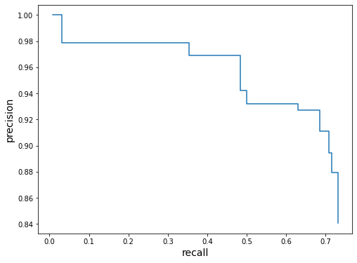

```
tensor(0.6937)
```

```python
print(calculate_AP(boxes_test, labels_test, scores_test, dataset_test, 0.75, 15))
```

### **Задание 4**. (12 баллов)

А вот теперь будем играться с моноклассовой модификацией детектора.

1. Замените головы нашего `SSD300` так, чтобы теперь он детектировал только один класс. Вы можете создать новый экземпляр класса с другим параметром и аккуратно подтащить веса, либо уже у существующего `pretrained` детектора заменить необходимые слои (2 балла)
2. Подготовьте код для обучения и тестирования. **Явно пропишите свои функции train_epoch** (3 балла), **evaluate** (2 балла).

Процедуры обучения и тестирования можно посмотреть тут: [ссылка 1](https://github.com/pytorch/vision/blob/master/references/detection/engine.py), [ссылка 2](https://github.com/multimodallearning/pytorch-mask-rcnn/blob/master/model.py#L1736), [ссылка 3](https://github.com/pytorch/vision/blob/0467c9d74c9b34f91df905ed8cf8433de48d7fa5/references/detection/coco_eval.py#L19). А ещё можно покопаться в одной из самых известных (но чуть более сложной чем у нас) реализаций [ssd на pytorch](https://github.com/amdegroot/ssd.pytorch).

1. Поэкспериментируйте и постарайтесь выйти на хорошее качество на test - **bbox AP@IoU=0.75 >=0.75**. Попробуйте поменять число голов, разные аугментации, lr, оптимайзеры, заморозку слоев и что ещё хочется (может быть самые смелые даже набор якорей попробуют поменять?). Напишите резюме - что получилсь, что позволило получить результат, а что нет. (5 баллов)

Какой результат? Что дает дополнительная настройка модели?

### 1.

```python
ssd_one_class = SSD300(n_classes = 2)
```

```
 Loaded backbone.
```

```python
ssd_one_class = ssd_one_class.to(device)
```

Изменим обученные веса, чтобы их можно было использовать в нашей модели. Отличия весов будут только головах. То есть надо изменить размерности weights и bias в pred_convs.cl_conv4_3, pred_convs.cl_conv7, pred_convs.cl_conv8_2, pred_convs.cl_conv9_2, pred_convs.cl_conv10_2, pred_convs.cl_conv11_2. Нужно первую размерность уменьшить в 21/2 раз

То есть из каждого 21 элемента нужно выбрать 0-ой и 15-ый, соответствующие классам background и person

```python
checkpoint2 = checkpoint.copy()
```

```python
for conv_name in ['pred_convs.cl_conv4_3.weight', 'pred_convs.cl_conv7.weight', 'pred_convs.cl_conv8_2.weight',
                  'pred_convs.cl_conv9_2.weight', 'pred_convs.cl_conv10_2.weight', 'pred_convs.cl_conv11_2.weight']:
    res = []
    for i in range(0,len(checkpoint2['state_dict'][conv_name]), 21):
        res.append(torch.concat([torch.unsqueeze(checkpoint2['state_dict'][conv_name][i],0), torch.unsqueeze(checkpoint2['state_dict'][conv_name][i+15],0)]))
    checkpoint2['state_dict'][conv_name] = torch.concat(res)
```

```python
for conv_name in ['pred_convs.cl_conv4_3.bias', 'pred_convs.cl_conv7.bias', 'pred_convs.cl_conv8_2.bias',
                  'pred_convs.cl_conv9_2.bias', 'pred_convs.cl_conv10_2.bias', 'pred_convs.cl_conv11_2.bias']:
    res = []
    for i in range(0,len(checkpoint2['state_dict'][conv_name]), 21):
        res.append(torch.concat([torch.unsqueeze(checkpoint2['state_dict'][conv_name][i],0), torch.unsqueeze(checkpoint2['state_dict'][conv_name][i+15],0)]))
    checkpoint2['state_dict'][conv_name] = torch.concat(res)
```

```python
ssd_one_class.load_state_dict(checkpoint2['state_dict'])
```

```
<All keys matched successfully>
```

### 2.

Обучение модели

```python
num_epochs = 10
batch_size = 15
lr = 3e-4

device = torch.device("cuda:0") if torch.cuda.is_available() else torch.device("cpu")
print(device)
```

```
cuda:0
```

```python
loss_fn = MultiBoxLoss(ssd_one_class.priors_cxcy)

optimizer = torch.optim.Adam(ssd_one_class.parameters(), lr=lr)

scheduler = ReduceLROnPlateau(optimizer, mode="min", factor=0.5, patience=1, verbose=True)
```

```python
'''
def run_epoch(stage, model, dataloader, loss_fn, optimizer, epoch, device):

    if stage == "train":
        model.train()
        torch.set_grad_enabled(True)
    else:
        torch.set_grad_enabled(False)
        model.eval()

    model = model.to(device)

    losses = []

    for batch in tqdm(dataloader, total=len(dataloader), desc=f"epoch: {str(epoch).zfill(3)} | {stage:5}"):
        images_bt, boxes_bt, labels_bt = batch

        predicted_locs, predicted_scores = model(images_bt.to(device))

        loss = loss_fn(predicted_locs, predicted_scores, boxes_bt, labels_bt)


        if stage == "train":
            loss.backward()
            optimizer.step()
            optimizer.zero_grad()

        losses.append(loss.detach().cpu().item())

    if stage == "train":
        scheduler.step(np.mean(losses))

    return np.mean(losses)
'''
```

```python
def train_epoch(model, dataloader, loss_fn, optimizer, epoch, device):

    model.train()
    torch.set_grad_enabled(True)
    model = model.to(device)

    losses = []

    for batch in tqdm(dataloader, total=len(dataloader), desc=f"epoch: {str(epoch).zfill(3)}"):
        images_bt, boxes_bt, labels_bt = batch

        predicted_locs, predicted_scores = model(images_bt.to(device))

        loss = loss_fn(predicted_locs, predicted_scores, boxes_bt, labels_bt)

        loss.backward()
        optimizer.step()
        optimizer.zero_grad()

        losses.append(loss.detach().cpu().item())

    scheduler.step(np.mean(losses))

    return np.mean(losses)
```

```python
def evaluate(model, dataloader, loss_fn, optimizer, epoch, device):

    torch.set_grad_enabled(False)
    model.eval()

    model = model.to(device)

    losses = []

    for batch in tqdm(dataloader, total=len(dataloader), desc=f"epoch: {str(epoch).zfill(3)}"):
        images_bt, boxes_bt, labels_bt = batch

        predicted_locs, predicted_scores = model(images_bt.to(device))

        loss = loss_fn(predicted_locs, predicted_scores, boxes_bt, labels_bt)

        losses.append(loss.detach().cpu().item())

    return np.mean(losses)
```

```python
def run_experiment(model, dataloader_train, dataloader_val, loss_fn, optimizer, num_epochs, device):

    train_losses = []
    val_losses = []

    for epoch in range(num_epochs):
        train_loss = train_epoch(model, dataloader_train, loss_fn, optimizer, epoch, device)
        train_losses.append(train_loss)

        val_loss = evaluate(model, dataloader_val, loss_fn, optimizer, epoch, device)
        val_losses.append(val_loss)

        print(f"epoch: {str(epoch).zfill(3)} | train_loss: {train_loss:5.3f}, val_loss: {val_loss:5.3f}")

    return train_losses, val_losses, model
```

### 3.

```python
# так как теперь только два класса, то изменим класс людей 15 на 1
class PedestrianSet_(object):
    def __init__(self, root, train, transforms):
        self.root = root
        self.transforms = transforms
        if train:
            images_path = self.root + '/Images/train/'
            masks_path = self.root + '/Masks/train/'
            # получим имена всех файлов в каталоге
            imgs = sorted(os.listdir(images_path))
            masks = sorted(os.listdir(masks_path))
            # сохраним полные пути к файлам
            imgs = list(map(lambda name: os.path.join(images_path, name), imgs))
            masks = list(map(lambda name: os.path.join(masks_path, name), masks))
            # оставим только файлы определённого типа
            self.imgs = list(filter(lambda x: x.endswith('.png'), imgs))
            self.masks = list(filter(lambda x: x.endswith('.png'), masks))
        else:
            images_path = self.root + '/Images/test/'
            masks_path = self.root + '/Masks/test/'
            # получим имена всех файлов в каталоге
            imgs = sorted(os.listdir(images_path))
            masks = sorted(os.listdir(masks_path))
            # сохраним полные пути к файлам
            imgs = list(map(lambda name: os.path.join(images_path, name), imgs))
            masks = list(map(lambda name: os.path.join(masks_path, name), masks))
            # оставим только файлы определённого типа
            self.imgs = list(filter(lambda x: x.endswith('.png'), imgs))
            self.masks = list(filter(lambda x: x.endswith('.png'), masks))


    def __getitem__(self, idx):

        # считываем картинку и маску с помощью PIL
        img = Image.open(self.imgs[idx])
        # маску сразу преобразуем в тензор
        mask = t(Image.open(self.masks[idx]))

        boxes = mask_to_boxes(mask)

        #хоть класс в данных всего один, надо верно выставить label на основании pascal voc
        labels = torch.tensor([1 for i in range(len(boxes))])

        if self.transforms is not None:
            img = self.transforms(img)
            #img = img.reshape(-1, 3, 300, 300)

        return img, boxes, labels

    def __len__(self):
        return len(self.imgs)

    def collate_fn(batch):
        images_batch = torch.zeros(len(batch), 3, 300, 300)
        boxes_batch = []
        labels_batch = []
        for i, item in enumerate(batch):
            images_batch[i] = item[0]
            boxes_batch.append(item[1])
            labels_batch.append(item[2])
        return images_batch, boxes_batch, labels_batch
```

```python
dataset_train = PedestrianSet_(path, True, transform)
dataset_test = PedestrianSet_(path, False, transform)
```

```python
dataloader_train = DataLoader(dataset_train,
                              collate_fn=PedestrianSet_.collate_fn,
                              batch_size=batch_size, shuffle=True, drop_last=True,
                              pin_memory=True)

dataloader_test = DataLoader(dataset_test,
                            collate_fn=PedestrianSet_.collate_fn,
                            batch_size=batch_size, shuffle=False, drop_last=False,
                            pin_memory=True)
```

```python
boxes_test, labels_test, scores_test = collect_predictions(ssd_one_class, dataloader_test, device, min_score, max_overlap, top_k)
```

```python
for i in range(len(boxes_test)):
    original_image = Image.open(dataset_test.imgs[i])
    original_dims = torch.FloatTensor([original_image.width, original_image.height, original_image.width, original_image.height]).unsqueeze(0)
    boxes_test[i] = boxes_test[i].to('cpu') * original_dims
```

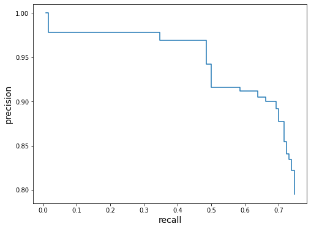

```
tensor(0.7013)
```

```python
print(calculate_AP(boxes_test, labels_test, scores_test, dataset_test, 0.75, 1))
```

Заметим, что качество уже немного подросло после изменения модели для 2 классов

## **Часть 3. Обработка видеопоследовательности (БОНУС!)**

Давайте теперь сделаем классный видеоролик. Видео для теста живет тут: https://www.epfl.ch/labs/cvlab/data/data-pom-index-php/

Берем оттуда **Campus sequences - [Seq.1, cam. 1].**

### **Задание 5**. (4 балла)

Пишем `Dataset` для видеопоследовательности. Впервые он будет иметь метод не `get_item`, а `iter`, так как по последовательности мы хотим пройти один раз и каждый кадр отправлять в сетку, посмотрите документацию по `IterableDataset` [тут](https://pytorch.org/docs/stable/data.html#torch.utils.data.IterableDataset). Можно использовать и обычный `Dataset`, но для `get_item` нам надо уметь получать видеокадр по конкретному индексу из видеопоследовательности, для `VideoCapture` этот метод работает плохо (возможны неточные выдергивания).

Так как это `eval` процедура, можете вообще не использовать `Dataset` и `Dataloader`, а читать последовательно кадры и оборачивать их в тензоры для сети.

Далее прогоняем картинки через сетку и для кадров собираем результаты детектирования (используйте в `DataLoader` `batch_size=1`, `num_workers=0` - иначе с `VideoCapture` могут возникнуть проблемы)

Пробегаем по последовательности ещё раз, рисуем на кадрах боксы как и задании 1 (цвет выберите один раз для всех масок чтобы каждый кадр он не мигал), собираем всё в видео. Видео присылайте вместе с заданием.

```python
# заготовка (можете не использовать, а написать по-своему)
class VideoSet(torch.utils.data.IterableDataset):
    """Dataset based on video file"""
    def __init__(self, video_path, transform):
        self.cap = cv2.VideoCapture(video_path)
        self.transform = transform

    def __iter__(self):
        self.cap.set(cv2.CAP_PROP_POS_FRAMES, 0) #поставили указатель начала чтения на самое начало
        frame_id = 0

        while True:
            status, image = self.cap.read()

            #тут допишите необходимые преобразования с image

            yield (frame_id, image)

            #а ещё frame_id надо менять если id нужен
```

```python
#прогоните каждый фрейм через сеть, получите и соберите где то все предсказания и
```

```python
#тут с помощью cv2.VideoCapture снова прочитайте видео, нарисуйте результаты на фреймах
```

### **Задание 6**. (4 балла)

Вспоминаем, что у нас ходят отдельные люди - сделайте простенький object tracking, где боксы соседних фреймов относятся к одному треку по IoU детекций.

Идея проста - если на фреймах `N+0` и `N+1` `IoU` двух боксов `> threshold`, то считаем что трек остался тот же - и для него сохраняем цвет визуализации бокса с фрейма `N`, если нет - заводим новый цвет. И учитываем что бокс может совпасть только с ОДНИМ боксом с предыдущего кадра. Процедура ровно та же что в детекторе спрятана.

Для тех же боксов и масок нарисуйте ещё одно видео - где каждый человек будет иметь **один** цвет **от начала до конца** своего присутствия в видео (фактически мы получим трек конкретного человека).

Видео прикладывайте к заданию, я обязательно оценю.

```python
#тут добавилась функция матчинга по IoU
```

```python
#а тут снова читаем видео, рисуем на фреймах боксы и маски учитывая их положения на предыдущем кадре и соответственно выбирая цвет, собираем новое видео
```

Иногда нерадивые люди утаскивают чужой бокс при неудачном пересечении, что делать, чтобы этого не случалось?